# False positive Control

Xinyi Lin

10/3/2020

Problems need to solve:

Why the batch of 123 for mutate and normal can be mapped to each other?

Try set up parameters and simulate with two small clusters and it doesn’t work. Try using expression parameters extract from HCC data for four clusters with one small clusters and six clusters with two small clusters. Do not work too. Seurat performs better with six clusters.

Try mnnCT7 parameters……

Seurat has the tendency to mark cells evenly for paired batch???

```r
library(splatter)
library(Seurat)
library(speckle)
library(DCATS)
library(ggplot2)
library(tidyverse)
library(diffcyt)
```

```r
source("functions.r")
```

## Experiment 6

Import data, we only need ‘GSE96583_batch2.total.tsne.df’

```r
GSE96583_batch2.total.tsne.df <- read.delim("D:/#Codes/R/Ho_DCATS/data/GSE96583_batch2.total.tsne.df.tsv")
summary(GSE96583_batch2.total.tsne.df)
# check NA
apply(is.na(GSE96583_batch2.total.tsne.df),2,sum)
```

No cluster have different proportion in ‘ctrl’ and ‘stim’ group.

```r
# data preprocessing
batchlabels <- GSE96583_batch2.total.tsne.df[,6][!is.na(GSE96583_batch2.total.tsne.df[,6])]
conditionlabels <- GSE96583_batch2.total.tsne.df[,4][!is.na(GSE96583_batch2.total.tsne.df[,6])]
batch2info <- table(conditionlabels,batchlabels)

# plotting
heat_matrix(batch2info,show_value = TRUE)
```

[output not shown]

```r
exp6_df = GSE96583_batch2.total.tsne.df %>%
  filter(!is.na(cell)) %>%
  group_by(cell, stim) %>%
  summarise(n = n()) %>%
  pivot_wider(names_from = "stim", values_from = "n")

exp6_mat = data.matrix(exp6_df[,c(2,3)])

params = splatEstimate(exp6_mat)
sim = splatSimulate(params)
```

Simulate our own data based on GSE96583_batch2.total.tsne.df

## Experiment 7

```r
# CR_Exp7_1
# data preprocessing
Fig6_tSNE <- read.delim("./data/Fig6_tSNE.txt")
subjectnameswhole <- Fig6_tSNE[,1]
subjectnameswhole <- subjectnameswhole[2:length(subjectnameswhole)]
celltypelabels <- gsub(".*_","",subjectnameswhole)
conditionnames <- gsub(".*[AGCT]_","",subjectnameswhole)
conditionnames <- gsub("_.*","",conditionnames)
subjectinfo <- table(conditionnames,celltypelabels)
micenames <- gsub("_.*","",subjectnameswhole)
indivsubjectnames <- sapply(seq_len(9842),function(t){paste(micenames[t],conditionnames[t],sep="_")})
indivsubjectinfo <- table(indivsubjectnames,celltypelabels)
properord <- c(1,3,4,5,6,7,8,9,10,2)
indivsubjectinfo <- sapply(properord,function(t){indivsubjectinfo[t,]})
indivsubjectinfo <- t(indivsubjectinfo)
rownames(indivsubjectinfo) <- unique(indivsubjectnames)
combinations <- t(combn(seq_len(4),2))
setupnames <- c("Control","Hpoly.Day3","Hpoly.Day10","Salmonella")
combination_setup <- list()
for (i in 1:6){
  k <- combinations[i,]
  a <- k[1]
  b <- k[2]
  comparisons_names <- paste(setupnames[a],"vs",setupnames[b],sep="_")
  combination_setup[[i]] <- comparisons_names
}
```

## HCC data

```r
HCC_seurat <- readRDS("/storage/holab/hcc_data/RDS_files/SCT/HCC.final.SCT_pc10_res0.1.rds")
count_HCC = HCC_seurat@assays$RNA@counts
params <- splatEstimate(as.matrix(count_HCC))
params
saveRDS(params, "./data/HCCparams.rds")
```

## mnnCT7

```r
mnnCT7_seurat <- readRDS("/storage/holab/Nelson/mnnCT7.rds")
count_mnnCT7 = mnnCT7_seurat@assays$RNA@counts
params <- splatEstimate(as.matrix(count_mnnCT7))
params
saveRDS(params, "./data/mnnCT7params.rds")
```

## Simulate data

### self set params

small cluster: 0.01-0.05

```r
set.seed(123)
probNor = c(0.57, 0.11, 0.31, 0.01)
probMut = c(0.57, 0.11, 0.31, 0.01)
setresolu = 0.15
batch_size = 22000
de_prob = c(0.15, 0.40, 0.02, 0.14)

sim_list = simualtion(probNor, probMut, de_prob, batch_size)
#integratedSamples = runSeurat(sim_list, batch_size, setresolu)
#saveRDS(integratedSamples, "./data/integratedSamples_neg.rds")
integratedSamples = readRDS("./data/integratedSamples_neg.rds")
conf.mat<-table(Idents(integratedSamples), sim_list$origLabels)
print(conf.mat)
```

```
##
##         1     2     3     4
##   A   524     0 40430  1321
##   B 41354     0   193     3
##   C 33462     0   131     8
##   D     0 14574     0     0
```

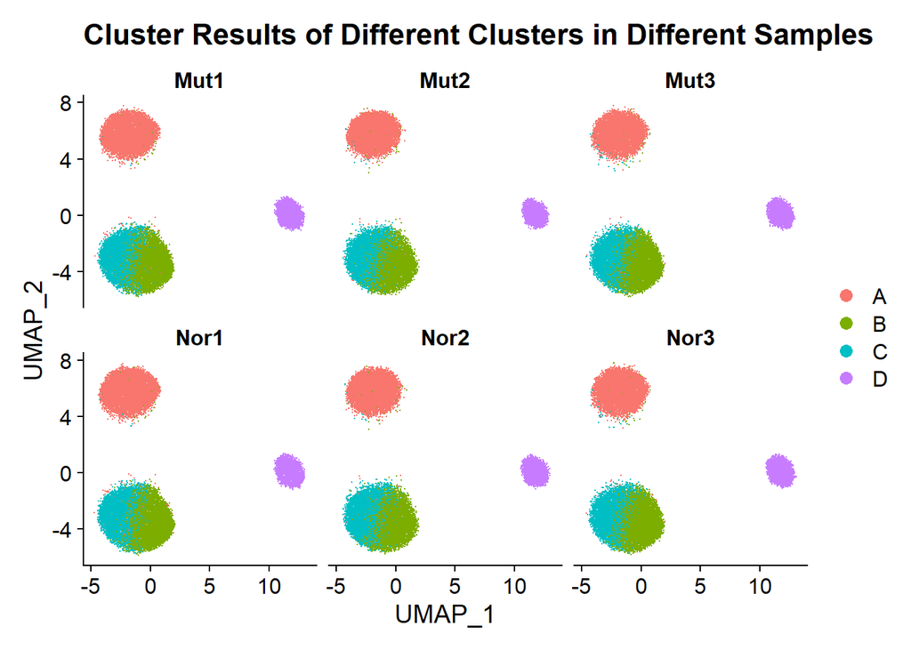

```r
plot = DimPlot(integratedSamples, ncol = 3, reduction = "umap", split.by = "batch") + ggtitle("Cluster Results of Different Clusters in Different Samples")
print(plot)
```

```r
Res = getPandTimeFSDD4(integratedSamples, sim_list, batch_size)
```

```
## group variable has 2 levels, t-tests will be performed
```

```
## FlowSOM clustering completed in 3.2 seconds
```

```r
print(Res)
```

```
## $Res_df
##   cluster dcats_pvalsT speckle_pvals dcats_pvalsI dcats_pvalsU dcats_pvalsK
## 1       A    0.9903771             1    0.9764693    0.9910744    0.9921484
## 2       B    0.9940914             1    0.7489455    0.9588806    0.9597761
## 3       C    0.9953809             1    0.7093027    0.9372103    0.9529713
## 4       D    1.0000000             1    1.0000000    0.9905188    1.0000000
##   fisher_pvals diffcyt_pvals
## 1    0.9830637             1
## 2    0.7769824             1
## 3    0.7348371             1
## 4    1.0000000             1
##
## $time_df
##   methods       time
## 1  fisher 0.21745086
## 2 sepckle 0.06582618
## 3   dcats 0.33722210
## 4 diffcyt 0.06305885
```

Try to use parameters extract from HCC data. Need to use parallel.

```r
library(future)
# check the current active plan
plan()
```

```
## sequential:
## - args: function (expr, envir = parent.frame(), substitute = TRUE, lazy = FALSE, seed = NULL, globals = TRUE, local = TRUE, earlySignal = FALSE, label = NULL, ...)
## - tweaked: FALSE
## - call: NULL
```

```r
# change the current plan to access parallelization
plan("multiprocess", workers = 4)
plan()
```

```
## multiprocess:
## - args: function (expr, envir = parent.frame(), substitute = TRUE, lazy = FALSE, seed = NULL, globals = TRUE, workers = 4, gc = FALSE, earlySignal = FALSE, label = NULL, ...)
## - tweaked: TRUE
## - call: plan("multiprocess", workers = 4)
```

```r
options(future.globals.maxSize = 2000 * 1024^2)
```

### HCC params

When clusters’ numbers equals to four

```r
set.seed(123)
probNor = c(0.57, 0.11, 0.31, 0.01)
probMut = c(0.57, 0.11, 0.31, 0.01)
setresolu = 0.08
batch_size = 20000
de_prob = c(0.15, 0.40, 0.02, 0.14)
```

```r
HCCparams = readRDS("./data/HCCparams.rds")
sim_list = simualtionRWD(probNor, probMut, de_prob, batch_size, params = HCCparams)
#integratedSamples = runSeurat(sim_list, batch_size, setresolu)
#saveRDS(integratedSamples, "./data/integratedSamples_HCC4.rds")
#sendEmail("Seurat is done!")
integratedSamples = readRDS("./data/integratedSamples_HCC4.rds")
conf.mat<-table(Idents(integratedSamples), sim_list$origLabels)
print(conf.mat)
```

```
##
##         1     2     3     4
##   A 28079  6312 17222   555
##   B 27506  4932 14541   467
##   C 10559  2032  5235   176
##   D  1786   202   378    18
```

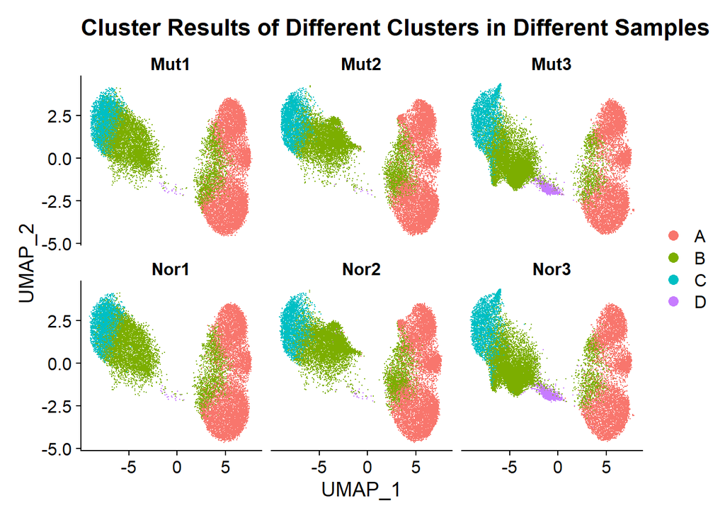

```r
plot = DimPlot(integratedSamples, ncol = 3, reduction = "umap", split.by = "batch") + ggtitle("Cluster Results of Different Clusters in Different Samples")
print(plot)
```

```r
Res = getPandTimeFSDD4(integratedSamples, sim_list, batch_size)
```

```
## group variable has 2 levels, t-tests will be performed
```

```
## FlowSOM clustering completed in 3.1 seconds
```

```r
print(Res)
```

```
## $Res_df
##   cluster dcats_pvalsT speckle_pvals dcats_pvalsI dcats_pvalsU dcats_pvalsK
## 1       A    0.9894657     0.9943555    0.7798460    0.9614425    0.9508030
## 2       B    0.9918110     0.9943555    0.7678340    0.9559658    0.9540626
## 3       C    0.9970335     0.9943555    0.9613138    0.9925923    0.9879848
## 4       D    0.9992421     0.9943555    0.8685518    0.9705950    0.9401399
##   fisher_pvals diffcyt_pvals
## 1    0.8160693         0.998
## 2    0.8017017         0.998
## 3    0.9690920         0.998
## 4    0.8854388         0.998
##
## $time_df
##   methods       time
## 1  fisher 0.17353511
## 2 sepckle 0.05158782
## 3   dcats 0.41631198
## 4 diffcyt 0.03091598
```

When clusters’ numbers equals to six

```r
set.seed(123)
probNor = c(0.52, 0.11, 0.20, 0.01, 0.01, 0.15)
probMut = c(0.52, 0.11, 0.20, 0.01, 0.01, 0.15)
setresolu = 0.15
batch_size = 10000
de_prob = c(0.15, 0.40, 0.02, 0.14, 0.02, 0.17)
```

```r
HCCparams = readRDS("./data/HCCparams.rds")
sim_list = simualtionRWD(probNor, probMut, de_prob, batch_size, params = HCCparams)
#integratedSamples = runSeurat(sim_list, batch_size, setresolu)
#saveRDS(integratedSamples, "./data/integratedSamples_HCC6.rds")
#sendEmail("Seurat is done!")
integratedSamples = readRDS("./data/integratedSamples_HCC6.rds")
conf.mat<-table(Idents(integratedSamples), sim_list$origLabels)
print(conf.mat)
```

```
##
##         1     2     3     4     5     6
##   A 11267    66  2954   106   138   251
##   B 14589     1   120    14    10    19
##   C  5091  1277  1630    56    74  1014
##   D    79    15  7013   389   388    73
##   E    19     4   158    10    14  7705
##   F    11  5399    21    11     6     8
```

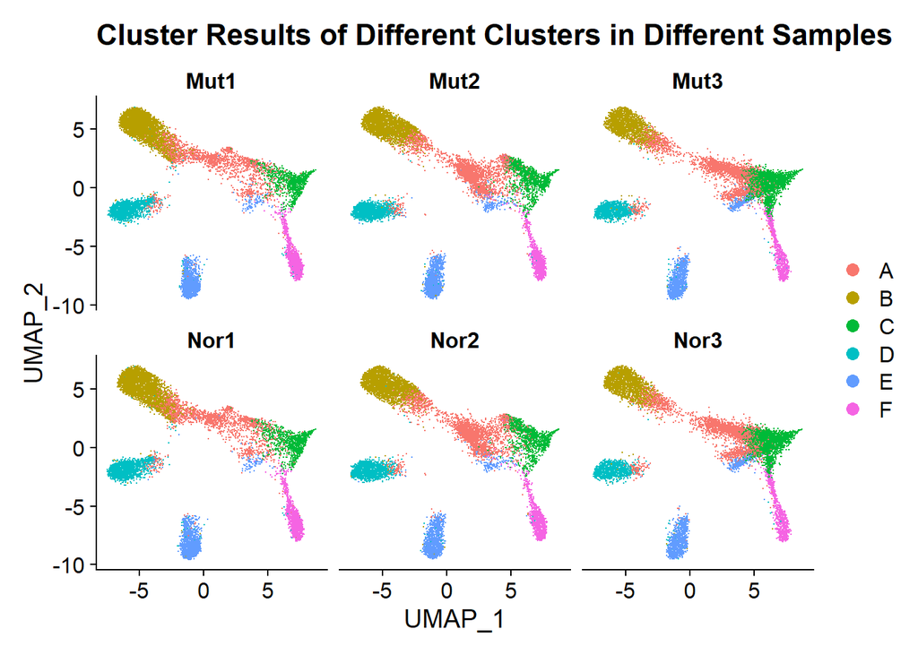

```r
plot = DimPlot(integratedSamples, ncol = 3, reduction = "umap", split.by = "batch") + ggtitle("Cluster Results of Different Clusters in Different Samples")
print(plot)
```

```r
Res = getPandTimeFSDD6(integratedSamples, sim_list, batch_size)
```

```
## group variable has 2 levels, t-tests will be performed
```

```
## FlowSOM clustering completed in 1.6 seconds
```

```r
print(Res)
```

```
## $Res_df
##   cluster dcats_pvalsT speckle_pvals dcats_pvalsI dcats_pvalsU dcats_pvalsK
## 1       A    0.9939976     0.9999267    0.8054227    0.9563979    0.9408538
## 2       B    0.9750404     0.9999267    0.7688331    0.9506505    0.9239408
## 3       C    0.9836222     0.9999267    0.9456586    0.9854922    0.9836369
## 4       D    0.9844053     0.9999267    0.9903961    0.9995155    0.9992669
## 5       E    0.9816878     0.9999267    1.0000000    0.9962449    0.9919930
## 6       F    0.9782247     0.9999267    1.0000000    0.9970095    0.9995456
##   fisher_pvals diffcyt_pvals
## 1    0.8261886             1
## 2    0.7919854             1
## 3    0.9566111             1
## 4    1.0000000             1
## 5    1.0000000             1
## 6    1.0000000             1
##
## $time_df
##   methods       time
## 1  fisher 0.08473516
## 2 sepckle 0.02097487
## 3   dcats 0.63433290
## 4 diffcyt 0.03258395
```

### mnnCT7params

When clusters’ numbers equals to six

```r
set.seed(123)
probNor = c(0.52, 0.11, 0.20, 0.01, 0.01, 0.15)
probMut = c(0.52, 0.11, 0.20, 0.01, 0.01, 0.15)
setresolu = 0.18
batch_size = 10000
de_prob = c(0.15, 0.40, 0.02, 0.14, 0.02, 0.17)
```

```r
mnnCT7params = readRDS("./data/mnnCT7params.rds")
sim_list = simualtionRWD(probNor, probMut, de_prob = mnnCT7params@de.prob, batch_size, params = mnnCT7params)
#integratedSamples = runSeurat(sim_list, batch_size, setresolu)
#saveRDS(integratedSamples, "./data/integratedSamples_mnn6.rds")
#sendEmail("Seurat is done!")
integratedSamples = readRDS("./data/integratedSamples_mnn6.rds")
conf.mat<-table(Idents(integratedSamples), sim_list$origLabels)
print(conf.mat)
```

```
##
##         1     2     3     4     5     6
##   A 15999    36   114   105   140   113
##   B 12355     6    24    38    69    73
##   C   163    49  7806   134    98   124
##   D   201    80   122   158   118  7580
##   E  2173   360  3791    58    60   962
##   F   165  6231    39    93   145   218
```

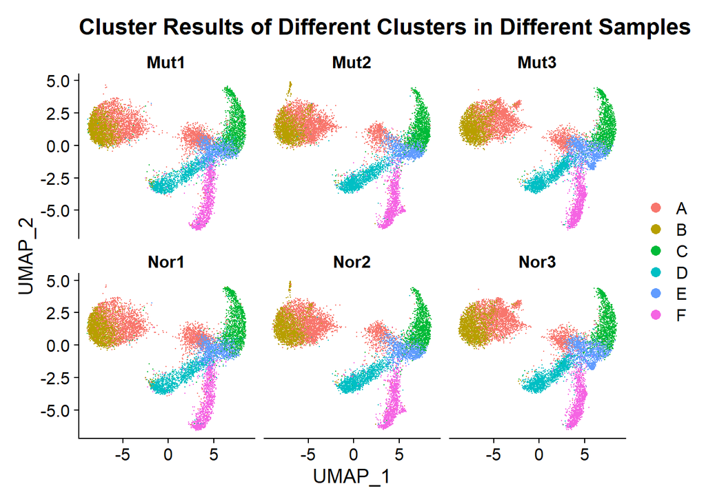

```r
plot = DimPlot(integratedSamples, ncol = 3, reduction = "umap", split.by = "batch") + ggtitle("Cluster Results of Different Clusters in Different Samples")
print(plot)
```

```r
Res = getPandTimeFSDD6(integratedSamples, sim_list, batch_size)
```

```
## group variable has 2 levels, t-tests will be performed
```

```
## FlowSOM clustering completed in 1.3 seconds
```

```r
print(Res)
```

```
## $Res_df
##   cluster dcats_pvalsT speckle_pvals dcats_pvalsI dcats_pvalsU dcats_pvalsK
## 1       A    0.9980509     0.9924986    0.8621058    0.9707722    0.9694461
## 2       B    0.9958051     0.9924986    0.8174963    0.9518155    0.9500438
## 3       C    0.9894760     0.9924986    0.7061848    0.9237715    0.9256662
## 4       D    0.9866129     0.9924986    0.9338949    0.9949867    0.9771210
## 5       E    0.9937029     0.9924986    0.6021352    0.9154741    0.8897000
## 6       F    0.9979064     0.9924986    0.9897841    0.9951692    0.9920269
##   fisher_pvals diffcyt_pvals
## 1    0.8800867         0.993
## 2    0.8356795         0.993
## 3    0.7254108         0.993
## 4    0.9454532         0.993
## 5    0.6227903         0.993
## 6    1.0000000         0.993
##
## $time_df
##   methods       time
## 1  fisher 0.08278012
## 2 sepckle 0.01791692
## 3   dcats 0.51764894
## 4 diffcyt 0.02493405
```

```r
sendEmail("knitr is done")
```

Try to set ‘de.downProb’ and ‘de.facLoc’.